# Assignment 2

- Show All Code
- Hide All Code
- View Source

Author

LO7G01

Published

October 15, 2025

# 1 Problem

Body fat percentage is an important diagnostic to know as it provides and accurate health assessment, can be used to manage risks of diseases, such as cardiovascular diseases and diabetes, and can inform fitness decisions to be targeted to an individual’s unique body composition. However, people usually rely on oversimplified indicators such as BMI (Body Mass Index) or expensive tests, which are not accessible to everyone, to understand their body fat percentage. Our project will thus investigate how simple, accessible body measurements such as weight, age, height and various body circumference measurements, can reliably predict body fat percentage. By building a model which can successfully predict body fat percentage, individuals will be better equipped to track their health and fitness status without the need for specialised equipment or professional testing.

# 2 EDA

```r
library(tidyverse)
library(readr)
# install.packages("modelsummary")
library(modelsummary)
library(ggcorrplot)
# install.packages("caTools")
library(caTools)
library(car)
# install.packages("sjPlot")
library(sjPlot)
library(insight)
# install.packages("lmSubsets")
library(lmSubsets)
theme_set(theme_bw())
```

## 2.1 Data Quality and Cleaning

```r
# Read in data and inspect
bodyfat <- read_tsv("bodyfat.txt")
glimpse(bodyfat)
```

```
Rows: 250
Columns: 16
$ Density <dbl> 1.0708, 1.0853, 1.0414, 1.0751, 1.0340, 1.0502, 1.0549, 1.0704…
$ Pct.BF  <dbl> 12.3, 6.1, 25.3, 10.4, 28.7, 20.9, 19.2, 12.4, 4.1, 11.7, 7.1,…
$ Age     <dbl> 23, 22, 22, 26, 24, 24, 26, 25, 25, 23, 26, 27, 32, 30, 35, 35…
$ Weight  <dbl> 154.25, 173.25, 154.00, 184.75, 184.25, 210.25, 181.00, 176.00…
$ Height  <dbl> 67.75, 72.25, 66.25, 72.25, 71.25, 74.75, 69.75, 72.50, 74.00,…
$ Neck    <dbl> 36.2, 38.5, 34.0, 37.4, 34.4, 39.0, 36.4, 37.8, 38.1, 42.1, 38…
$ Chest   <dbl> 93.1, 93.6, 95.8, 101.8, 97.3, 104.5, 105.1, 99.6, 100.9, 99.6…
$ Abdomen <dbl> 85.2, 83.0, 87.9, 86.4, 100.0, 94.4, 90.7, 88.5, 82.5, 88.6, 8…
$ Waist   <dbl> 33.54331, 32.67717, 34.60630, 34.01575, 39.37008, 37.16535, 35…
$ Hip     <dbl> 94.5, 98.7, 99.2, 101.2, 101.9, 107.8, 100.3, 97.1, 99.9, 104.…
$ Thigh   <dbl> 59.0, 58.7, 59.6, 60.1, 63.2, 66.0, 58.4, 60.0, 62.9, 63.1, 59…
$ Knee    <dbl> 37.3, 37.3, 38.9, 37.3, 42.2, 42.0, 38.3, 39.4, 38.3, 41.7, 39…
$ Ankle   <dbl> 21.9, 23.4, 24.0, 22.8, 24.0, 25.6, 22.9, 23.2, 23.8, 25.0, 25…
$ Bicep   <dbl> 32.0, 30.5, 28.8, 32.4, 32.2, 35.7, 31.9, 30.5, 35.9, 35.6, 32…
$ Forearm <dbl> 27.4, 28.9, 25.2, 29.4, 27.7, 30.6, 27.8, 29.0, 31.1, 30.0, 29…
$ Wrist   <dbl> 17.1, 18.2, 16.6, 18.2, 17.7, 18.8, 17.7, 18.8, 18.2, 19.2, 18…
```

```r
# Type cast to be integer as measured in years
bodyfat$Age <- as.integer(bodyfat$Age)
glimpse(bodyfat)
```

```
Rows: 250
Columns: 16
$ Density <dbl> 1.0708, 1.0853, 1.0414, 1.0751, 1.0340, 1.0502, 1.0549, 1.0704…
$ Pct.BF  <dbl> 12.3, 6.1, 25.3, 10.4, 28.7, 20.9, 19.2, 12.4, 4.1, 11.7, 7.1,…
$ Age     <int> 23, 22, 22, 26, 24, 24, 26, 25, 25, 23, 26, 27, 32, 30, 35, 35…
$ Weight  <dbl> 154.25, 173.25, 154.00, 184.75, 184.25, 210.25, 181.00, 176.00…
$ Height  <dbl> 67.75, 72.25, 66.25, 72.25, 71.25, 74.75, 69.75, 72.50, 74.00,…
$ Neck    <dbl> 36.2, 38.5, 34.0, 37.4, 34.4, 39.0, 36.4, 37.8, 38.1, 42.1, 38…
$ Chest   <dbl> 93.1, 93.6, 95.8, 101.8, 97.3, 104.5, 105.1, 99.6, 100.9, 99.6…
$ Abdomen <dbl> 85.2, 83.0, 87.9, 86.4, 100.0, 94.4, 90.7, 88.5, 82.5, 88.6, 8…
$ Waist   <dbl> 33.54331, 32.67717, 34.60630, 34.01575, 39.37008, 37.16535, 35…
$ Hip     <dbl> 94.5, 98.7, 99.2, 101.2, 101.9, 107.8, 100.3, 97.1, 99.9, 104.…
$ Thigh   <dbl> 59.0, 58.7, 59.6, 60.1, 63.2, 66.0, 58.4, 60.0, 62.9, 63.1, 59…
$ Knee    <dbl> 37.3, 37.3, 38.9, 37.3, 42.2, 42.0, 38.3, 39.4, 38.3, 41.7, 39…
$ Ankle   <dbl> 21.9, 23.4, 24.0, 22.8, 24.0, 25.6, 22.9, 23.2, 23.8, 25.0, 25…
$ Bicep   <dbl> 32.0, 30.5, 28.8, 32.4, 32.2, 35.7, 31.9, 30.5, 35.9, 35.6, 32…
$ Forearm <dbl> 27.4, 28.9, 25.2, 29.4, 27.7, 30.6, 27.8, 29.0, 31.1, 30.0, 29…
$ Wrist   <dbl> 17.1, 18.2, 16.6, 18.2, 17.7, 18.8, 17.7, 18.8, 18.2, 19.2, 18…
```

Need to also convert `Weight`, which is currently in pounds, to kg and `Height`, which is currently in inches, to cm.

```r
bodyfat$Weight <- bodyfat$Weight/2.205
bodyfat$Height <- bodyfat$Height*2.54
```

```r
glimpse(bodyfat)
```

```
Rows: 250
Columns: 16
$ Density <dbl> 1.0708, 1.0853, 1.0414, 1.0751, 1.0340, 1.0502, 1.0549, 1.0704…
$ Pct.BF  <dbl> 12.3, 6.1, 25.3, 10.4, 28.7, 20.9, 19.2, 12.4, 4.1, 11.7, 7.1,…
$ Age     <int> 23, 22, 22, 26, 24, 24, 26, 25, 25, 23, 26, 27, 32, 30, 35, 35…
$ Weight  <dbl> 69.95465, 78.57143, 69.84127, 83.78685, 83.56009, 95.35147, 82…
$ Height  <dbl> 172.085, 183.515, 168.275, 183.515, 180.975, 189.865, 177.165,…
$ Neck    <dbl> 36.2, 38.5, 34.0, 37.4, 34.4, 39.0, 36.4, 37.8, 38.1, 42.1, 38…
$ Chest   <dbl> 93.1, 93.6, 95.8, 101.8, 97.3, 104.5, 105.1, 99.6, 100.9, 99.6…
$ Abdomen <dbl> 85.2, 83.0, 87.9, 86.4, 100.0, 94.4, 90.7, 88.5, 82.5, 88.6, 8…
$ Waist   <dbl> 33.54331, 32.67717, 34.60630, 34.01575, 39.37008, 37.16535, 35…
$ Hip     <dbl> 94.5, 98.7, 99.2, 101.2, 101.9, 107.8, 100.3, 97.1, 99.9, 104.…
$ Thigh   <dbl> 59.0, 58.7, 59.6, 60.1, 63.2, 66.0, 58.4, 60.0, 62.9, 63.1, 59…
$ Knee    <dbl> 37.3, 37.3, 38.9, 37.3, 42.2, 42.0, 38.3, 39.4, 38.3, 41.7, 39…
$ Ankle   <dbl> 21.9, 23.4, 24.0, 22.8, 24.0, 25.6, 22.9, 23.2, 23.8, 25.0, 25…
$ Bicep   <dbl> 32.0, 30.5, 28.8, 32.4, 32.2, 35.7, 31.9, 30.5, 35.9, 35.6, 32…
$ Forearm <dbl> 27.4, 28.9, 25.2, 29.4, 27.7, 30.6, 27.8, 29.0, 31.1, 30.0, 29…
$ Wrist   <dbl> 17.1, 18.2, 16.6, 18.2, 17.7, 18.8, 17.7, 18.8, 18.2, 19.2, 18…
```

### 2.1.1 Missingness

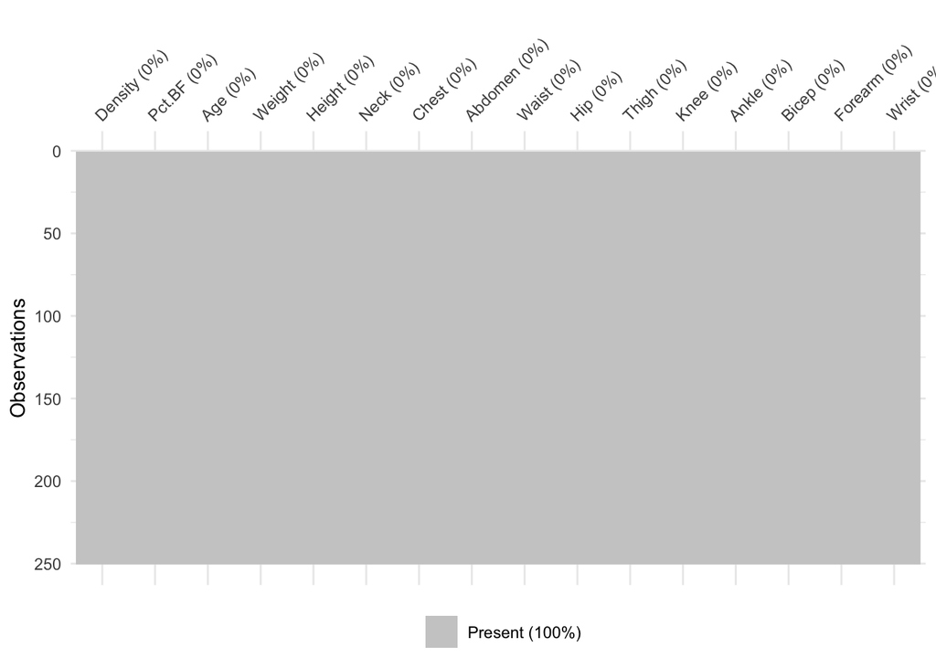

```r
visdat::vis_miss(bodyfat, sort_miss = TRUE) + # Sort the variables in descending order of missingness
  theme(axis.text.bodyfat = element_text(angle = 90, hjust = 0))
```

No missing values are inputted and as all variable types are numeric, there are no string inputs such as ‘None’ to represent NA values. Therefore, the data is complete.

### 2.1.2 Summary statistics

Unique

Missing Pct.

Mean

SD

Min

Median

Max

Histogram

Density

217

0

1.1

0.0

1.0

1.1

1.1

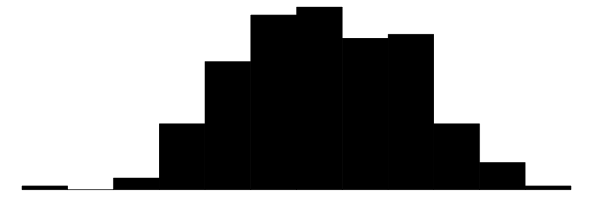

Pct.BF

175

0

19.0

8.3

0.0

19.2

47.5

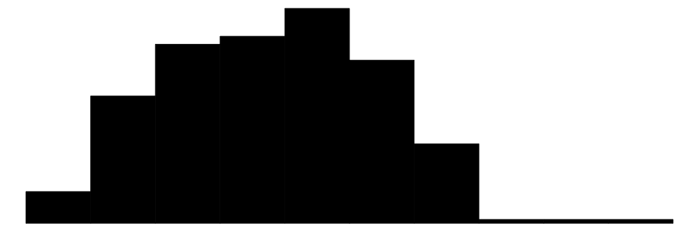

Age

51

0

44.9

12.7

22.0

43.0

81.0

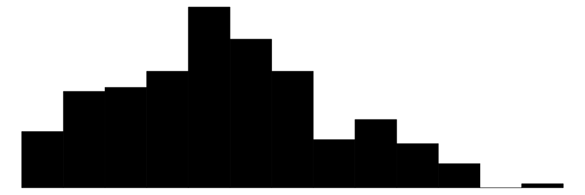

Weight

195

0

80.8

12.3

53.7

79.9

119.2

[figure not shown]

Height

47

0

178.6

6.6

162.6

177.8

197.5

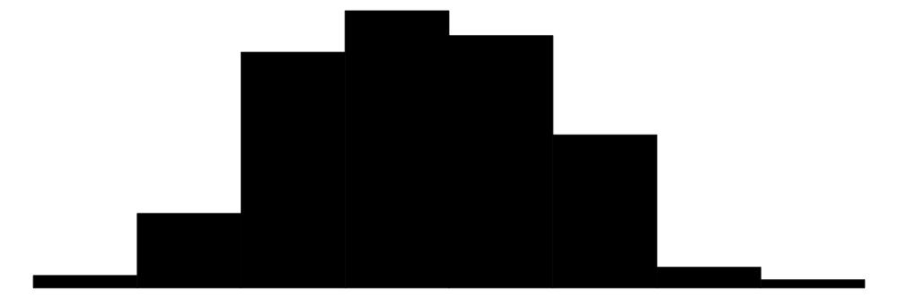

Neck

89

0

37.9

2.3

31.1

38.0

43.9

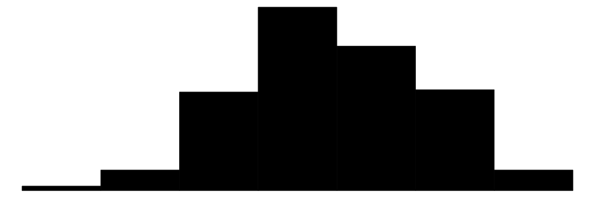

Chest

172

0

100.7

8.2

79.3

99.6

128.3

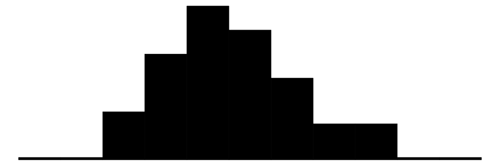

Abdomen

184

0

92.3

10.2

69.4

90.9

126.2

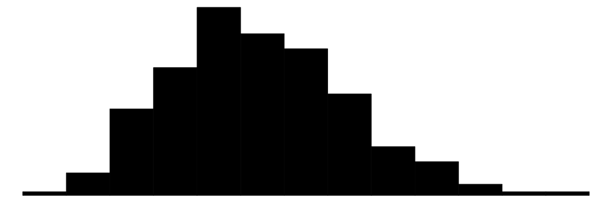

Waist

184

0

36.3

4.0

27.3

35.8

49.7

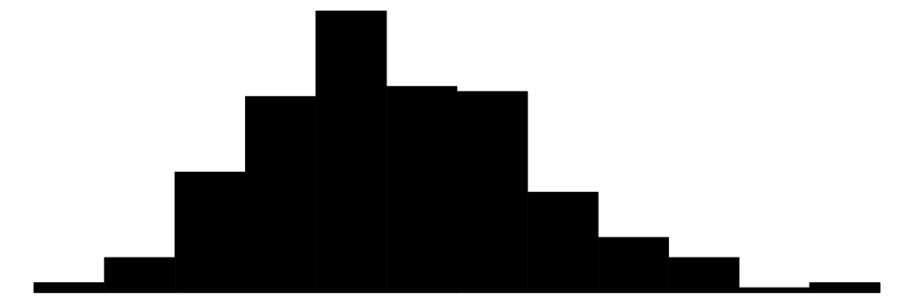

Hip

150

0

99.7

6.4

85.0

99.3

125.6

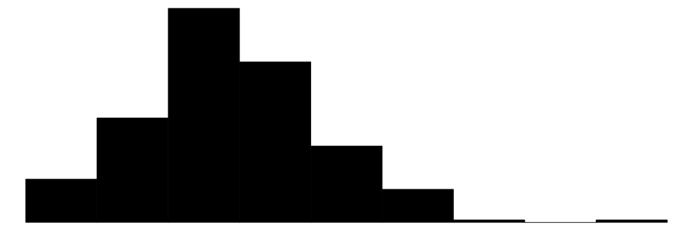

Thigh

137

0

59.2

4.9

47.2

59.0

74.4

[figure not shown]

Knee

89

0

38.5

2.3

33.0

38.5

46.0

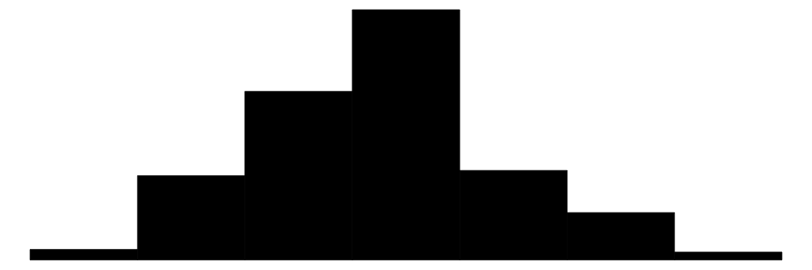

Ankle

60

0

23.1

1.7

19.1

22.8

33.9

[4 more figures not shown]

```r
datasummary_skim(bodyfat)
```

## 2.2 Dependent Variable

The dependent variable that our group is going to predict is body fat percentage (`Pct.BF`). So as part of the EDA process, I will first visualise the distribution of this variable.

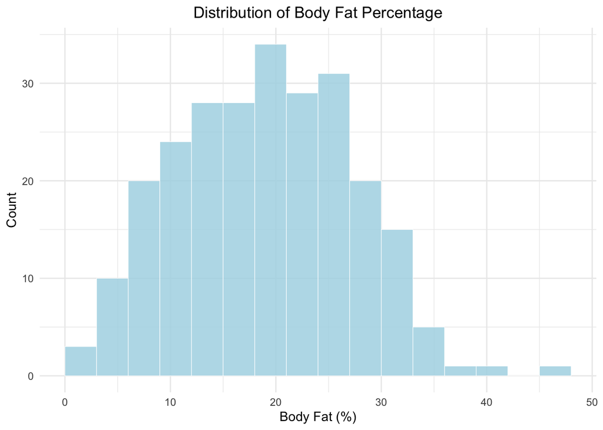

```r
ggplot(bodyfat) +
  aes(x = Pct.BF) +
  geom_histogram(binwidth = 3, boundary = 0, position = "identity",
                 alpha = 0.85, fill = "lightblue", colour = "white", size = 0.2) +
labs(title = "Distribution of Body Fat Percentage", x = "Body Fat (%)", y = "Count") +
  theme_minimal() +
  theme(plot.title = element_text(hjust = 0.5))
```

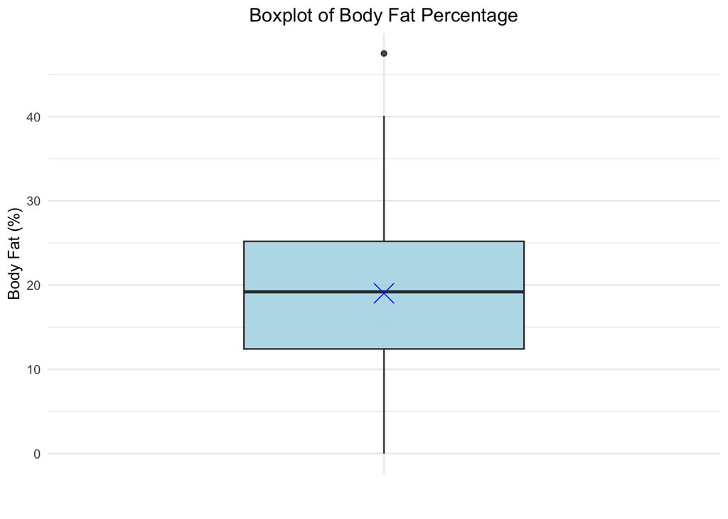

```r
# Calculate mean
bfp_mean <- mean(bodyfat$Pct.BF)

ggplot(bodyfat) +
  aes(x = "", y = Pct.BF) +
  geom_boxplot(alpha = 0.85, fill = "lightblue", width = 0.5) +
  stat_summary(fun = mean, geom = "point", shape = 4, size = 6, color = "blue") +
labs(title = "Boxplot of Body Fat Percentage", y = "Body Fat (%)", x = "") +
  theme_minimal() +
  theme(plot.title = element_text(hjust = 0.5))
```

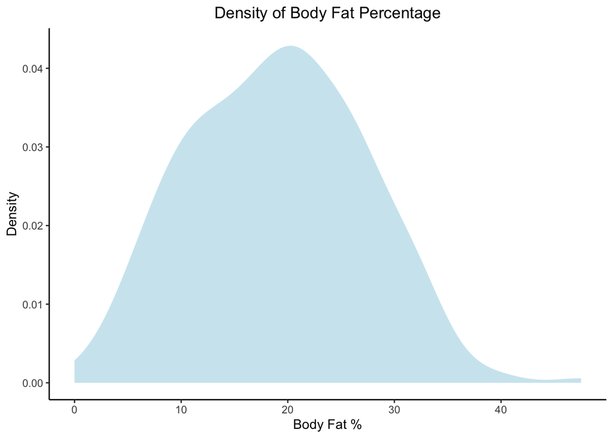

```r
ggplot(bodyfat) +
  aes(x = Pct.BF) +
  geom_density(fill = "lightblue", colour="white", alpha = 0.6) +
  labs(title = "Density of Body Fat Percentage", x = "Body Fat %", y = "Density") +
  theme_classic() +
  theme(plot.title = element_text(hjust = 0.5))
```

The investigation into the body fat percentage dependent variable (`Pct.bf`) has revealed that the distribution of this variable is approximately bell-shaped with a slight right skew, driven by a small number of individuals with unusually high body fat percentages above approximately 40%. These cases appear as outliers in the boxplot, which also explains the longer right tail in the histogram and density plots. Despite this mild skewness, the variable appears to be fairly symmetric, with a mean and median very close together. Therefore, no immediate transformation is required as the distribution is suited for modelling purposes and does not exhibit strong non-linearities.

## 2.3 Independent Variables

This section investigates the relationships between body fat percentage and other variables in the dataset, focusing on those that exhibit stronger correlations or meaningful dynamics with the dependent variable.

### 2.3.1 Correlation Analysis

```r
datasummary_correlation(bodyfat)
```

|  | Density | Pct.BF | Age | Weight | Height | Neck | Chest | Abdomen | Waist | Hip | Thigh | Knee | Ankle | Bicep | Forearm | Wrist |
| --- | --- | --- | --- | --- | --- | --- | --- | --- | --- | --- | --- | --- | --- | --- | --- | --- |
| Density | 1 | . | . | . | . | . | . | . | . | . | . | . | . | . | . | . |
| Pct.BF | -.99 | 1 | . | . | . | . | . | . | . | . | . | . | . | . | . | . |
| Age | -.28 | .30 | 1 | . | . | . | . | . | . | . | . | . | . | . | . | . |
| Weight | -.60 | .62 | -.02 | 1 | . | . | . | . | . | . | . | . | . | . | . | . |
| Height | .04 | -.03 | -.25 | .51 | 1 | . | . | . | . | . | . | . | . | . | . | . |
| Neck | -.47 | .49 | .12 | .81 | .32 | 1 | . | . | . | . | . | . | . | . | . | . |
| Chest | -.68 | .70 | .18 | .89 | .22 | .77 | 1 | . | . | . | . | . | . | . | . | . |
| Abdomen | -.81 | .82 | .24 | .87 | .19 | .73 | .91 | 1 | . | . | . | . | . | . | . | . |
| Waist | -.81 | .82 | .24 | .87 | .19 | .73 | .91 | 1.00 | 1 | . | . | . | . | . | . | . |
| Hip | -.62 | .63 | -.06 | .93 | .40 | .71 | .82 | .86 | .86 | 1 | . | . | . | . | . | . |
| Thigh | -.54 | .55 | -.22 | .85 | .35 | .67 | .71 | .74 | .74 | .88 | 1 | . | . | . | . | . |
| Knee | -.48 | .49 | .02 | .84 | .51 | .65 | .70 | .71 | .71 | .81 | .78 | 1 | . | . | . | . |
| Ankle | -.24 | .24 | -.11 | .58 | .39 | .43 | .45 | .41 | .41 | .52 | .50 | .59 | 1 | . | . | . |
| Bicep | -.48 | .48 | -.04 | .79 | .32 | .71 | .71 | .66 | .66 | .72 | .74 | .65 | .45 | 1 | . | . |
| Forearm | -.35 | .36 | -.09 | .68 | .32 | .66 | .60 | .53 | .53 | .60 | .60 | .58 | .43 | .70 | 1 | . |
| Wrist | -.32 | .34 | .22 | .73 | .40 | .73 | .64 | .60 | .60 | .63 | .54 | .66 | .54 | .61 | .60 | 1 |

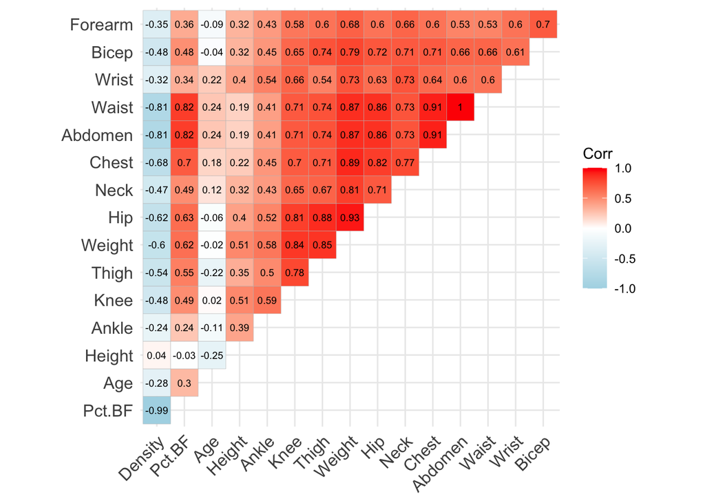

```r
cor_matrix <- round(cor(bodyfat, use = "complete.obs"),2)

ggcorrplot(cor_matrix,
           hc.order=TRUE,
           type = "upper",
           lab = TRUE,
           lab_size = 2.5,
           colors = c("lightblue", "white", "red"))
```

### 2.3.2 Relationships

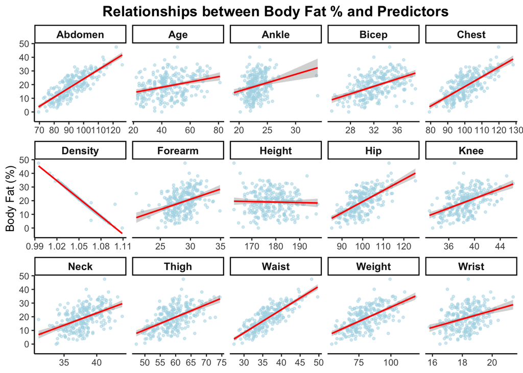

```r
# All predictors
vars_to_plot <- c("Density", "Abdomen","Waist","Chest","Hip","Weight","Thigh",
                  "Neck","Knee","Bicep","Forearm","Wrist","Age","Ankle","Height")

bodyfat |>
  select(Pct.BF, all_of(vars_to_plot)) |>
  pivot_longer(cols = all_of(vars_to_plot),
               names_to = "variable", values_to = "value") |>
  drop_na() |> ggplot() +
  aes(x = value, y = Pct.BF) +
  geom_point(alpha = 0.5, colour = "lightblue", size = 0.9) +
  geom_smooth(method = "lm", se = TRUE, colour = "red", linewidth = 0.7) +
  facet_wrap(~ variable, scales = "free_x", ncol = 5) +
  labs(x = NULL, y = "Body Fat (%)",
       title = "Relationships between Body Fat % and Predictors") +
  theme_classic() +
  theme(legend.position = "top",
        strip.text = element_text(size = 10, face="bold"),
        plot.title = element_text(size = 14, face="bold", hjust=0.5))
```

The scatterplots further confirm that body fat percentage has the strongest positive relationships with abdomen and waist size, closely followed by chest, hip and weight. Variables such as height and ankle show little association. While density also shows an almost perfect relationship, it provides negligible predictive value due its direct correlation to body fat percentage. Overall, torso-related measures seem to be the strongest predictors of body fat percentage.

#### 2.3.2.1 Deriving Categorical BMI variable

Using the guidelines at https://www.health.gov.au/topics/overweight-and-obesity/bmi-and-waist.

```r
bodyfat_wBMI <- bodyfat |>
  mutate(
    BMI = Weight/((Height/100)^2),               # Weight(kg) / Height^2(m)
    BMI_cat = case_when(
      BMI < 18.5 ~ "Underweight",
      BMI >= 18.5 & BMI < 25 ~ "Healthy",
      BMI >= 25 & BMI < 30 ~ "Overweight",
      BMI >= 30 & BMI < 35 ~ "Obese class 1",
      BMI >= 35 & BMI < 40 ~ "Obese class 2",
      BMI >= 40 ~ "Obese class 3"
    ),
    BMI_cat = factor(BMI_cat,
                     levels = c("Underweight", "Healthy",
                                "Overweight",
                                "Obese class 1", "Obese class 2", "Obese class 3"),
                     ordered = TRUE)
  )
```

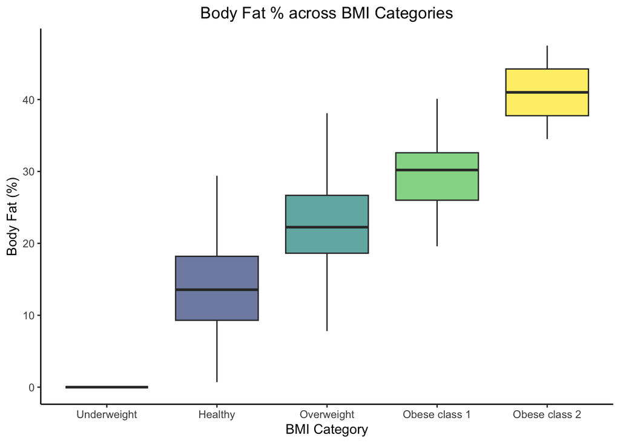

```r
ggplot(bodyfat_wBMI, aes(x = BMI_cat, y = Pct.BF, fill = BMI_cat)) +
  geom_boxplot(alpha = 0.7) +
  labs(title = "Body Fat % across BMI Categories",
       x = "BMI Category", y = "Body Fat (%)") +
  theme_classic() +
  theme(legend.position = "none",
        plot.title = element_text(hjust = 0.5))
```

This boxplot shows that body fat percentage rises consistently across BMI categories, confirming that higher BMI is strongly associated with higher body fat levels.

# 3 Model Selection

## 3.1 Data Splitting

First, splitting the data into training and test set to allow out-of-sample performance to be assessed and ensure no overfitting.

```r
set.seed(71) # Set random seed

split <- sample.split(bodyfat$Pct.BF, SplitRatio = 0.8)
train <- subset(bodyfat, split == TRUE)
test <- subset(bodyfat, split == FALSE)
```

```r
cat("Training set size (80%):", nrow(train), "\n")
```

```
Training set size (80%): 200
```

```r
cat("Test set size (20%):", nrow(test), "\n")
```

```
Test set size (20%): 50
```

## 3.2 Basic Models

### 3.2.1 Null Model

```r
M0 = lm(Pct.BF ~ 1, data=train) # Null Model
round(summary(M0)$coef, 3)
```

```
            Estimate Std. Error t value Pr(>|t|)
(Intercept)   18.682       0.59  31.648        0
```

### 3.2.2 Full Model

```r
M1 = lm(Pct.BF ~., data=train) # Full Model
round(summary(M1)$coef, 3)
```

```
            Estimate Std. Error t value Pr(>|t|)
(Intercept)  484.598      7.690  63.013    0.000
Density     -438.310      5.452 -80.400    0.000
Age            0.008      0.006   1.330    0.185
Weight         0.016      0.031   0.505    0.614
Height        -0.021      0.015  -1.407    0.161
Neck           0.027      0.048   0.567    0.572
Chest         -0.003      0.022  -0.141    0.888
Abdomen       -0.006      0.022  -0.272    0.786
Hip            0.024      0.030   0.792    0.429
Thigh         -0.001      0.030  -0.030    0.976
Knee          -0.048      0.046  -1.045    0.297
Ankle          0.016      0.039   0.424    0.672
Bicep         -0.003      0.032  -0.082    0.934
Forearm        0.005      0.037   0.129    0.897
Wrist         -0.098      0.104  -0.944    0.347
```

In the full model, majority of predictors are statistically insignificant (with `Pr(>|t|)` > 0.05) and this is potentially due to multicollinearity

```r
tryCatch({
  vif(M1)
}, error = function(e) {
  message("Error shown intentionally: ", e$message)
})
```

```
Error shown intentionally: there are aliased coefficients in the model
```

```r
alias(M1)
```

```
Model :
Pct.BF ~ Density + Age + Weight + Height + Neck + Chest + Abdomen +
    Waist + Hip + Thigh + Knee + Ankle + Bicep + Forearm + Wrist

Complete :
      (Intercept) Density Age    Weight Height Neck   Chest  Abdomen Hip
Waist      0           0       0      0      0      0      0 50/127       0
      Thigh  Knee   Ankle  Bicep  Forearm Wrist
Waist      0      0      0      0      0       0
```

This shows that waist and abdomen are nearly perfectly correlated, therefore going to fix the full model as such:

```r
M1_fixed <- lm(Pct.BF ~ Density + Age + Weight + Height + Neck + Chest +
                Abdomen + Hip + Thigh + Knee + Ankle + Bicep + Forearm +                 Wrist, data = train)
summary(M1_fixed)
```

```
Call:
lm(formula = Pct.BF ~ Density + Age + Weight + Height + Neck +
    Chest + Abdomen + Hip + Thigh + Knee + Ankle + Bicep + Forearm +
    Wrist, data = train)

Residuals:
    Min      1Q  Median      3Q     Max
-8.2875 -0.1255 -0.0092  0.1412  4.2361

Coefficients:
              Estimate Std. Error t value Pr(>|t|)
(Intercept)  4.846e+02  7.690e+00  63.013   <2e-16 ***
Density     -4.383e+02  5.452e+00 -80.400   <2e-16 ***
Age          8.040e-03  6.043e-03   1.330    0.185
Weight       1.574e-02  3.116e-02   0.505    0.614
Height      -2.119e-02  1.506e-02  -1.407    0.161
Neck         2.692e-02  4.752e-02   0.567    0.572
Chest       -3.050e-03  2.165e-02  -0.141    0.888
Abdomen     -5.857e-03  2.155e-02  -0.272    0.786
Hip          2.374e-02  2.996e-02   0.792    0.429
Thigh       -8.924e-04  2.968e-02  -0.030    0.976
Knee        -4.804e-02  4.597e-02  -1.045    0.297
Ankle        1.645e-02  3.882e-02   0.424    0.672
Bicep       -2.640e-03  3.207e-02  -0.082    0.934
Forearm      4.811e-03  3.718e-02   0.129    0.897
Wrist       -9.774e-02  1.036e-01  -0.944    0.347
---
Signif. codes:  0 '***' 0.001 '**' 0.01 '*' 0.05 '.' 0.1 ' ' 1

Residual standard error: 0.7159 on 185 degrees of freedom
Multiple R-squared:  0.9932,    Adjusted R-squared:  0.9926
F-statistic:  1920 on 14 and 185 DF,  p-value: < 2.2e-16
```

```r
vif(M1_fixed)
```

```
  Density       Age    Weight    Height      Neck     Chest   Abdomen       Hip
 4.022067  2.339816 58.647763  3.725533  4.750399 12.825167 19.432216 15.074229
    Thigh      Knee     Ankle     Bicep   Forearm     Wrist
 8.150967  4.547854  1.774522  3.446366  2.306119  3.581941
```

There’s high mutlicollinearity in this model (in variables with VIF > 5), therefore, we can try different models selection methods.

## 3.3 Stepwise Selection

### 3.3.1 Backwards Stepwise

```r
step.back.aic = step(M1_fixed,
                    direction = "backward",
                    trace = FALSE)
summary(step.back.aic)
```

```
Call:
lm(formula = Pct.BF ~ Density + Height + Hip, data = train)

Residuals:
    Min      1Q  Median      3Q     Max
-8.4534 -0.1239  0.0087  0.1290  4.2494

Coefficients:
              Estimate Std. Error  t value Pr(>|t|)
(Intercept)  4.858e+02  4.255e+00  114.167   <2e-16 ***
Density     -4.407e+02  3.674e+00 -119.949   <2e-16 ***
Height      -2.060e-02  9.119e-03   -2.259   0.0250 *
Hip          2.149e-02  1.142e-02    1.882   0.0613 .
---
Signif. codes:  0 '***' 0.001 '**' 0.01 '*' 0.05 '.' 0.1 ' ' 1

Residual standard error: 0.703 on 196 degrees of freedom
Multiple R-squared:  0.993, Adjusted R-squared:  0.9929
F-statistic:  9289 on 3 and 196 DF,  p-value: < 2.2e-16
```

### 3.3.2 Forward Stepwise

```r
step.fwd.aic = step(M0, scope = list(lower = M0, upper = M1_fixed),
                    direction = "forward", trace = FALSE)
summary(step.fwd.aic)
```

```
Call:
lm(formula = Pct.BF ~ Density + Height + Weight, data = train)

Residuals:
    Min      1Q  Median      3Q     Max
-8.4185 -0.1249  0.0079  0.1310  4.2900

Coefficients:
              Estimate Std. Error  t value Pr(>|t|)
(Intercept)  486.47250    3.89333  124.950   <2e-16 ***
Density     -439.63460    3.91097 -112.411   <2e-16 ***
Height        -0.02488    0.01018   -2.443   0.0154 *
Weight         0.01365    0.00675    2.023   0.0445 *
---
Signif. codes:  0 '***' 0.001 '**' 0.01 '*' 0.05 '.' 0.1 ' ' 1

Residual standard error: 0.702 on 196 degrees of freedom
Multiple R-squared:  0.993, Adjusted R-squared:  0.9929
F-statistic:  9315 on 3 and 196 DF,  p-value: < 2.2e-16
```

### 3.3.3 Comparing Stepwise Models

```r
sjPlot::tab_model(step.fwd.aic, step.back.aic,
                  show.ci = FALSE,
                  show.aic = TRUE,
                  dv.labels = c("Forward model", "Backward model"))
```

|  | Forward model |  | Backward model |  |
| --- | --- | --- | --- | --- |
| Predictors | Estimates | p | Estimates | p |
| (Intercept) | 486.47 | **<0.001** | 485.77 | **<0.001** |
| Density | -439.63 | **<0.001** | -440.67 | **<0.001** |
| Height | -0.02 | **0.015** | -0.02 | **0.025** |
| Weight | 0.01 | **0.044** |  |  |
| Hip |  |  | 0.02 | 0.061 |
| Observations | 200 |  | 200 |  |
| R<sup>2</sup> / R<sup>2</sup> adjusted | 0.993 / 0.993 |  | 0.993 / 0.993 |  |
| AIC | 432.004 |  | 432.553 |  |

## 3.4 Exhaustive Search

```r
exh = lmSubsets(Pct.BF ~ ., data = train, nbest = 15)
```

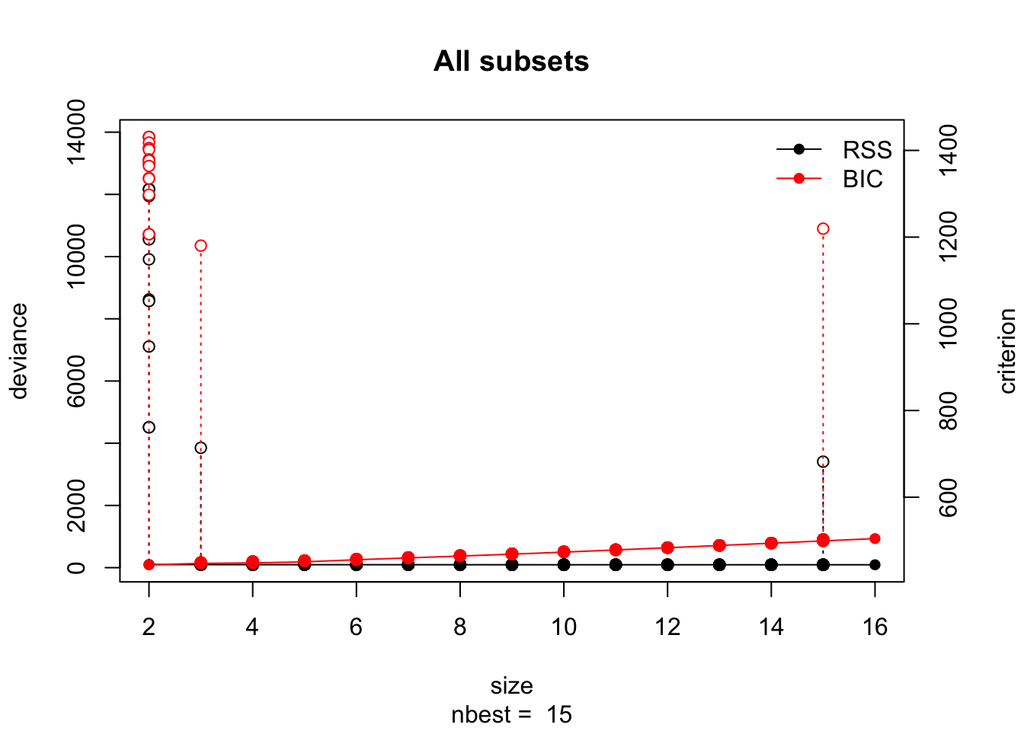

```r
plot(exh)
```

The best model chosen from the exhaustive search is as such:

```r
best_exh <- lmSelect(exh, criterion = "AIC")
# Refit chosen model
best_model <- lm(formula(best_exh), data = train)
summary(best_model)
```

```
Call:
lm(formula = formula(best_exh), data = train)

Residuals:
    Min      1Q  Median      3Q     Max
-8.2875 -0.1255 -0.0092  0.1412  4.2361

Coefficients: (1 not defined because of singularities)
              Estimate Std. Error t value Pr(>|t|)
(Intercept)  4.846e+02  7.690e+00  63.013   <2e-16 ***
Density     -4.383e+02  5.452e+00 -80.400   <2e-16 ***
Age          8.040e-03  6.043e-03   1.330    0.185
Weight       1.574e-02  3.116e-02   0.505    0.614
Height      -2.119e-02  1.506e-02  -1.407    0.161
Neck         2.692e-02  4.752e-02   0.567    0.572
Chest       -3.050e-03  2.165e-02  -0.141    0.888
Abdomen     -5.857e-03  2.155e-02  -0.272    0.786
Waist               NA         NA      NA       NA
Hip          2.374e-02  2.996e-02   0.792    0.429
Thigh       -8.924e-04  2.968e-02  -0.030    0.976
Knee        -4.804e-02  4.597e-02  -1.045    0.297
Ankle        1.645e-02  3.882e-02   0.424    0.672
Bicep       -2.640e-03  3.207e-02  -0.082    0.934
Forearm      4.811e-03  3.718e-02   0.129    0.897
Wrist       -9.774e-02  1.036e-01  -0.944    0.347
---
Signif. codes:  0 '***' 0.001 '**' 0.01 '*' 0.05 '.' 0.1 ' ' 1

Residual standard error: 0.7159 on 185 degrees of freedom
Multiple R-squared:  0.9932,    Adjusted R-squared:  0.9926
F-statistic:  1920 on 14 and 185 DF,  p-value: < 2.2e-16
```

## 3.5 Summary of Simple Model Search

```r
# Predictions on test set
pred_full <- predict(M1_fixed, newdata = test)
pred_fwd  <- predict(step.fwd.aic, newdata = test)
pred_back <- predict(step.back.aic, newdata = test)
pred_exh  <- predict(best_model, newdata = test)
```

```r
# Helper function
RMSE <- function(actual, predicted) sqrt(mean((actual - predicted)^2))
```

```r
y_test <- test$Pct.BF

results <- data.frame(
  Model = c("Full Model", "Forward Stepwise", "Backward Stepwise",                  "Exhaustive (BIC)"),
  RMSE  = c(RMSE(y_test, pred_full),
            RMSE(y_test, pred_fwd),
            RMSE(y_test, pred_back),
            RMSE(y_test, pred_exh))
)

print(results)
```

```
              Model     RMSE
1        Full Model 2.591034
2  Forward Stepwise 2.598651
3 Backward Stepwise 2.609384
4  Exhaustive (BIC) 2.591034
```

## 3.6 Multiple body section

```r
correlations <- cor(bodyfat[, c("Pct.BF", "Abdomen", "Chest", "Waist", "Hip",
                                "Bicep", "Forearm", "Wrist",
                                "Neck",
                                "Thigh", "Knee", "Ankle")], use = "complete.obs")

correlations["Pct.BF", ]
```

```
   Pct.BF   Abdomen     Chest     Waist       Hip     Bicep   Forearm     Wrist
1.0000000 0.8236846 0.7006696 0.8236847 0.6326747 0.4815382 0.3647089 0.3390078
     Neck     Thigh      Knee     Ankle
0.4885242 0.5485496 0.4923077 0.2445556
```

The variables most correlated with body fat percentage from each body section are: Abdomen (torso), Bicep (arms), Neck (neck/head), and Thigh (legs). Abdomen and waist show the strongest correlation overall (r = 0.82).

### 3.6.1 Regression equation and Interpretation

```r
lm1 <- lm(Pct.BF ~ Abdomen + Bicep + Neck + Thigh, data = bodyfat)
lm1
```

```
Call:
lm(formula = Pct.BF ~ Abdomen + Bicep + Neck + Thigh, data = bodyfat)

Coefficients:
(Intercept)      Abdomen        Bicep         Neck        Thigh
  -21.48054      0.83698      0.06487     -0.82439     -0.12723
```

Our estimates model is:

$\widehat{\text{Pct.BF}} = -21.48 + 0.84 \, \text{Abdomen} + 0.065 \, \text{Bicep} - 0.82 \, \text{Neck} - 0.13 \, \text{Thigh}$

The estimated coefficients represent the predicted change in body fat percentage for a one-unit increase in each predictor, holding all other variables constant.

- A one-centimeter increase in Abdomen circumference is associated with a 0.84% increase in body fat percentage on average, holding Bicep, Neck, and Thigh constant.
- A one-centimeter increase in Bicep circumference is associated with a 0.07% increase in body fat percentage, but this effect is not statistically significant (p = 0.69).
- A one-centimeter increase in Neck circumference is associated with a 0.82% decrease in body fat percentage on average, holding other variables constant.
- A one-centimeter increase in Thigh circumference is associated with a 0.13% decrease, but this effect is not statistically significant (p = 0.21).

This suggests that Abdomen size is the strongest predictor of body fat, while Neck has a moderate negative association.

### 3.6.2 **Model Performance**

```r
summary(lm1)
```

```
Call:
lm(formula = Pct.BF ~ Abdomen + Bicep + Neck + Thigh, data = bodyfat)

Residuals:
     Min       1Q   Median       3Q      Max
-10.2737  -3.5317  -0.0628   3.1989  13.3688

Coefficients:
             Estimate Std. Error t value Pr(>|t|)
(Intercept) -21.48054    5.08187  -4.227 3.35e-05 ***
Abdomen       0.83698    0.04713  17.758  < 2e-16 ***
Bicep         0.06487    0.16247   0.399    0.690
Neck         -0.82439    0.20481  -4.025 7.59e-05 ***
Thigh        -0.12723    0.10076  -1.263    0.208
---
Signif. codes:  0 '***' 0.001 '**' 0.01 '*' 0.05 '.' 0.1 ' ' 1

Residual standard error: 4.527 on 245 degrees of freedom
Multiple R-squared:  0.7069,    Adjusted R-squared:  0.7021
F-statistic: 147.7 on 4 and 245 DF,  p-value: < 2.2e-16
```

The regression model shows that abdomen circumference and neck circumference are significant predictors of body fat percentage (p < 0.001). Specifically, body fat increases with larger abdomen size and decreases with larger neck size. The model explains about 70% of the variation in body fat (Adjusted R² = 0.70), indicating a strong overall fit.

### 3.6.3 Model diagnostics

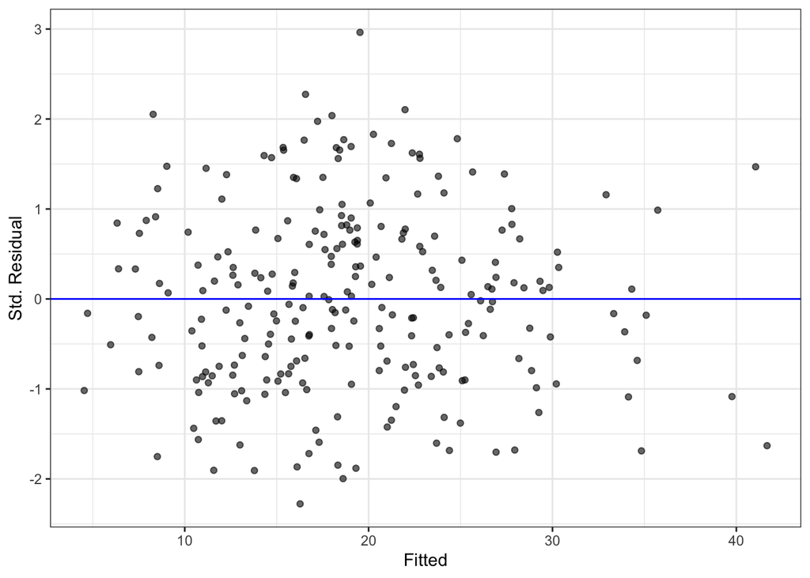

```r
library(broom)
aug <- augment(lm1)
ggplot(aug, aes(.fitted, .std.resid)) +
  geom_point(alpha = 0.6) +
  geom_hline(yintercept = 0, color = "blue") +
  labs(x = "Fitted", y = "Std. Residual")
```

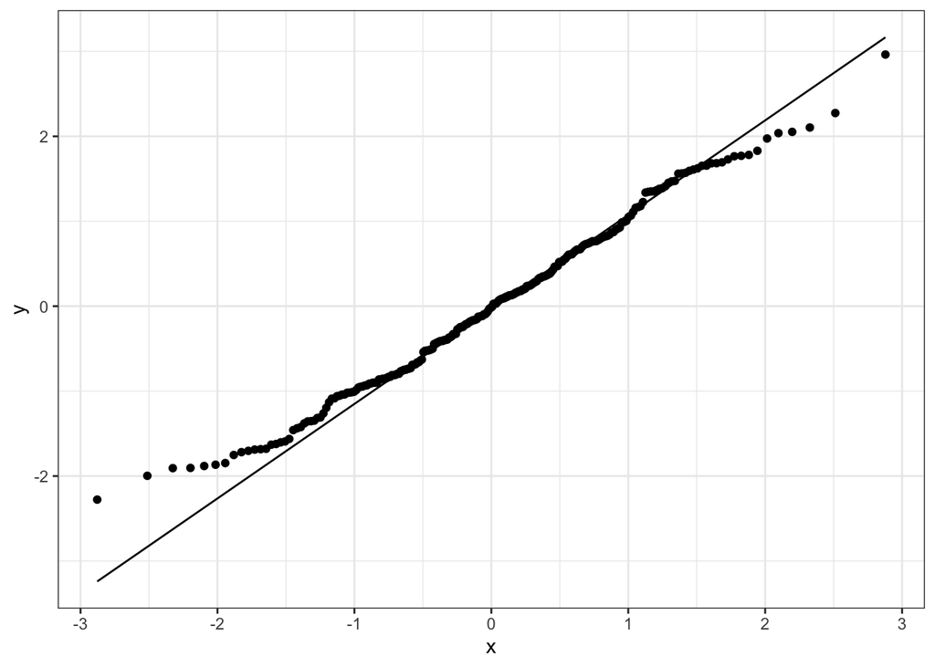

```r
ggplot(aug, aes(sample = .std.resid)) +
  stat_qq() +
  stat_qq_line()
```

The residual vs fitted plot shows no clear pattern, suggesting that the assumptions of linearity and constant variance are reasonably satisfied.  
The Q-Q plot indicates that residuals follow a roughly normal distribution, with only slight deviations at the tails.  
Overall, the diagnostic plots suggest that the regression model fits the data adequately and meets key model assumptions.